# Fall 2020 - Math 421 - Midterm

# Instruction

The midterm has two components: the Rmarkdown notebook (html) and the presentation. The notebook and the presentation file are due Nov 26. We will do the presentation in class

**The notebook:** The notebook should be created using `rmarkdown` (like other assignments). The notebook should have a title.

**The Presentation:** Present your results in 5-10 minutes. To make the presentation using Rmarkdown, do the follows:

```
- In Rstudio -> File -> New File -> R markdown

- In the left panel, click to Presentation -> Click OK

- Now you have an Rmarkdown that can be knitted to be a html presentation
```

**What to present**:

- Present Part 2 - Visualization
- Present Question Question 4, 5 and 6 in Part 3.
- Present any errors/challenges you run into and how you fix/overcome them.

**Data:**

The data for the mid-term project is the Rhode Island Department of Health Hospital Discharge Data. Each row of the data presents a patient.

Link: https://drive.google.com/open?id=15QNBf6YYKocK2nNIfpKDer58kQnCPNZJ

## I. Data Wranggling

1. Download the data file `hdd0318cy.sas7bdat`.
2. Use `read_sas` in library `haven` to read the data.

```r
library(haven)
df <- read_sas("C:/Users/student/Documents/GitHub/emmaschwartz1.github.io/hdd0318cy.sas7bdat")
```

3. Filter the data to have only patients of the year 2018 (`yod==2018`)

```r
library(tidyverse)
df <- df %>% filter(yod==18)
```

4. Select to work with only following variables:

```r
                      "yod", "payfix","pay_ub92","age",
                      "sex","raceethn","provider","moa",
                      "yoa","mod","admtype", "asource" ,
                      "preopday" ,"los", "service" , "icu","ccu",
                      "dispub92", "payer"  ,"drg","trandb",
                      "randbg","randbs","orr", "anes","seq",
                      "lab","dtest", "ther","blood","phar",
                      "other","patcon","bwght","total","tot" ,
                      "ecodub92","b_wt","pt_state","diag_adm","ancilar" ,
                      "campus","er_fee","er_chrg","er_mode","obs_chrg",
                      "obs_hour","psycchrg","nicu_day"
```

```r
df <- df %>% select(yod, payfix,pay_ub92,age,
                      sex,raceethn,provider,moa,
                      yoa,mod,admtype, asource ,
                      preopday ,los, service , icu,ccu,
                      dispub92,payer ,drg,trandb,
                      randbg,randbs,orr, anes,seq,
                      lab,dtest, ther,blood,phar,
                      other,patcon,bwght,total,tot ,
                      ecodub92,b_wt,pt_state,diag_adm,ancilar ,
                      campus,er_fee,er_chrg,er_mode,obs_chrg,
                      obs_hour,psycchrg,nicu_day)
```

*Notice*: You may want to save the current data to your computer for easy access later. To save the data file use `write_csv(df, 'midterm.csv')`, for example.

```r
write_csv(df, "midterm.csv")
```

5. What are variables that have missing values?

```r
colSums(is.na(df))
```

```
##      yod   payfix pay_ub92      age      sex raceethn provider      moa
##        0   131478        0        0        0        0        0        0
##      yoa      mod  admtype  asource preopday      los  service      icu
##        0        0        0        0    60486        0        0        0
##      ccu dispub92    payer      drg   trandb   randbg   randbs      orr
##        0        0        0        0        0        0        0        0
##     anes      seq      lab    dtest     ther    blood     phar    other
##        0        0        0        0        0        0        0        0
##   patcon    bwght    total      tot ecodub92     b_wt pt_state diag_adm
##        0        0        0        0        0        0        0        0
##  ancilar   campus   er_fee  er_chrg  er_mode obs_chrg obs_hour psycchrg
##        0        0        0        0        0        0    77343        0
## nicu_day
##   124090
```

6. Remove all variables with missing values

```r
df$payfix <- NULL
df$preopday <- NULL
df$obs_hour <- NULL
df$nicu_day <- NULL
```

7. Refer to the data description in the file `HDD2015-18cy6-20-19.docx`, which variable recording the month of admission?, which variable recording the month of discharge?

```r
#month of admission is MOA and month of discharge is MOD
```

8. Which month admitted the most number of patients? Which month admitted the most number of male patients?

```r
table1 <- table(df$moa)
table
```

[output not shown]

[output cut: 55 more lines]

[output not shown]

```r
#October has the greatest number of admitted patients

df1 <- df %>% filter(sex=="1")
table2 <- table(df1$moa)
table2
```

[output not shown]

```
##
##    1    2    3    4    5    6    7    8    9   10   11   12
## 4970 4546 4978 4989 5066 4810 4910 5028 4683 5164 4800 4855
```

```r
#October has the greatest number of admitted male patients
```

9. Which month has the most number of teenage female patients?

```r
df1 <- df %>% filter(sex=="2") %>%
  filter(age > 12 & age < 20)
table3 <-table(df1$moa)
table3
```

```
##
##   1   2   3   4   5   6   7   8   9  10  11  12
## 207 172 226 187 220 169 171 172 196 212 177 208
```

```r
#March has the greatest number of admitted teenage female patients
```

10. Which provider has the most number of female patients in October?

```r
df1 <- df %>% filter(moa==10 & sex =="2")
table4 <- table(df1$provider)
table4
```

```
##
## 7201 7202 7204 7205 7206 7209 7210 7211 7213 7214 7215 7216
##  294  212  872 1517  333  351  699  122  317 1224   46  256
```

```r
#Provider 7205 (Rhode Island Hospital) has the greatest number of female patients in October
```

11. Is female patients older than male patients, on average?

```r
df %>% group_by(sex) %>%
  summarize(mean(age))
```

```
## # A tibble: 3 x 2
##   sex   `mean(age)`
##   <chr>       <dbl>
## 1 1            51.5
## 2 2            50.9
## 3 9            43
```

```r
#No, male patients are older than female patients on average by a little more than half a year
```

12. Calculate the average age of patients by months. Which month has the oldest patients on average age?

```r
df %>% group_by(moa) %>%
  summarize(mean(age))
```

```
## # A tibble: 12 x 2
##      moa `mean(age)`
##    <dbl>       <dbl>
##  1     1        51.8
##  2     2        51.2
##  3     3        51.1
##  4     4        51.4
##  5     5        50.6
##  6     6        51.5
##  7     7        51.3
##  8     8        50.9
##  9     9        50.6
## 10    10        50.8
## 11    11        51.0
## 12    12        51.5
```

```r
#January has the oldest patients on average
```

13. What is the name of the provider that has the highest total charge?

```r
df %>% group_by(provider) %>%
  summarise(max(tot))
```

```
## # A tibble: 12 x 2
##    provider `max(tot)`
##    <chr>         <dbl>
##  1 7201         365044
##  2 7202        1477944
##  3 7204        1040507
##  4 7205        2991708
##  5 7206         802758
##  6 7209         282223
##  7 7210        1375171
##  8 7211         331604
##  9 7213         608086
## 10 7214        3402056
## 11 7215        2418518
## 12 7216        1532326
```

```r
#Provider 7214 (Women and Infants) has the highest total charge
```

14. What is the name of the provider that has the least total charge for teenage male on average?

```r
df %>% filter(sex=="1" & age <20 & age >12) %>%
  group_by(provider) %>%
  summarise(mean(tot))
```

```
## # A tibble: 12 x 2
##    provider `mean(tot)`
##    <chr>          <dbl>
##  1 7201          14434.
##  2 7202          29389.
##  3 7204          24989.
##  4 7205          40215.
##  5 7206          10360.
##  6 7209          26573.
##  7 7210          18586.
##  8 7211          19742.
##  9 7213          22618.
## 10 7214          28950
## 11 7215         100440.
## 12 7216          24060.
```

```r
#Provider 7206 (Roger Williams) has the least total charge for teenage male on average
```

15. Calculate the length of stays by races. Which race has the longest length of stays on average?

```r
df %>% group_by(raceethn) %>%
  summarise(mean(los))
```

```
## # A tibble: 8 x 2
##   raceethn `mean(los)`
##   <chr>          <dbl>
## 1 ""              4.38
## 2 "1"             4.93
## 3 "2"             5.28
## 4 "3"             4.41
## 5 "4"             5.54
## 6 "6"             5.35
## 7 "7"             4.67
## 8 "9"             6.18
```

```r
#Unknown has the longest length of stays on average, but American Indian, not Hispanic has the longest other than that
```

16. On average, how much a 20 year-old male white get charged for staying 1 day?

```r
df %>% filter(sex=="1" & age==20 & raceethn==1 & los==1) %>%
  summarise(mean(tot))
```

```
## # A tibble: 1 x 1
##   `mean(tot)`
##         <dbl>
## 1      15320.
```

```r
#15,319.56 on average
```

## II. Data Visualization

Continue with the data from part I.

1. Provides at least 10 meaningful plots. Comments on the plots. All plots should have title, caption, appropriate labels on x and y-axis

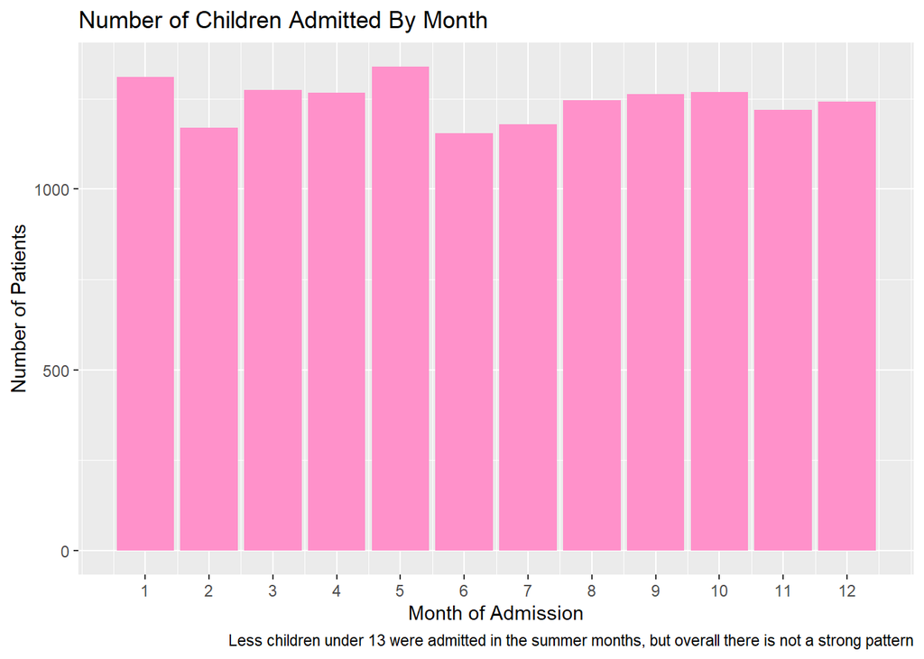

```r
library(ggplot2)

df %>% filter(age < 13) %>%
  ggplot() +
  geom_bar(mapping = aes(x = moa), fill = "#FF91CA")+
  labs(x = 'Month of Admission',
       y = 'Number of Patients',
       title = 'Number of Children Admitted By Month',
       caption = 'Less children under 13 were admitted in the summer months, but overall there is not a strong pattern') +
  scale_x_continuous(breaks = seq(1,12, by=1)) +
  ggsave("plot1.png")
```

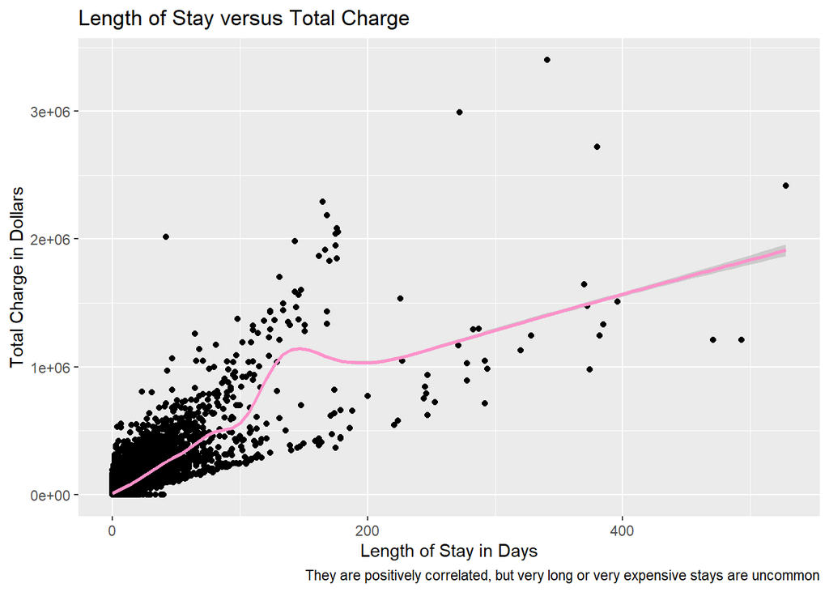

```r
df %>%
  ggplot() +
  geom_point(mapping = aes(x = los, y = tot))+
  geom_smooth(mapping = aes(x = los, y = tot), color = "#FF91CA")+
  labs(x = 'Length of Stay in Days',
       y = 'Total Charge in Dollars',
       title = 'Length of Stay versus Total Charge',
       caption = 'They are positively correlated, but very long or very expensive stays are uncommon')+
  ggsave("plot2.png")
```

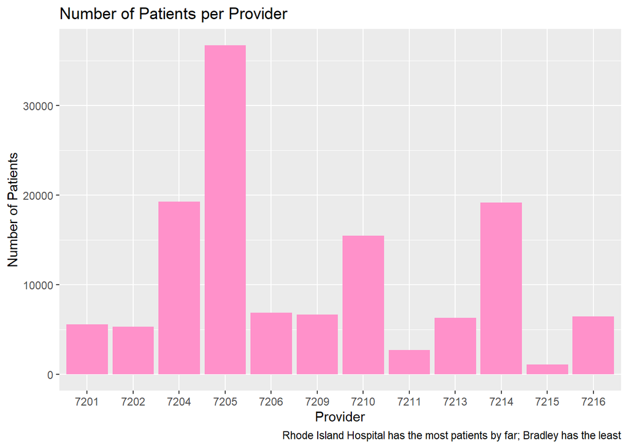

```r
df %>%
  ggplot()+
  geom_bar(mapping = aes(x = provider), fill = "#FF91CA")+
  labs(x = 'Provider',
       y = 'Number of Patients',
       title = 'Number of Patients per Provider',
       caption = 'Rhode Island Hospital has the most patients by far; Bradley has the least')+
  ggsave("plot3.png")
```

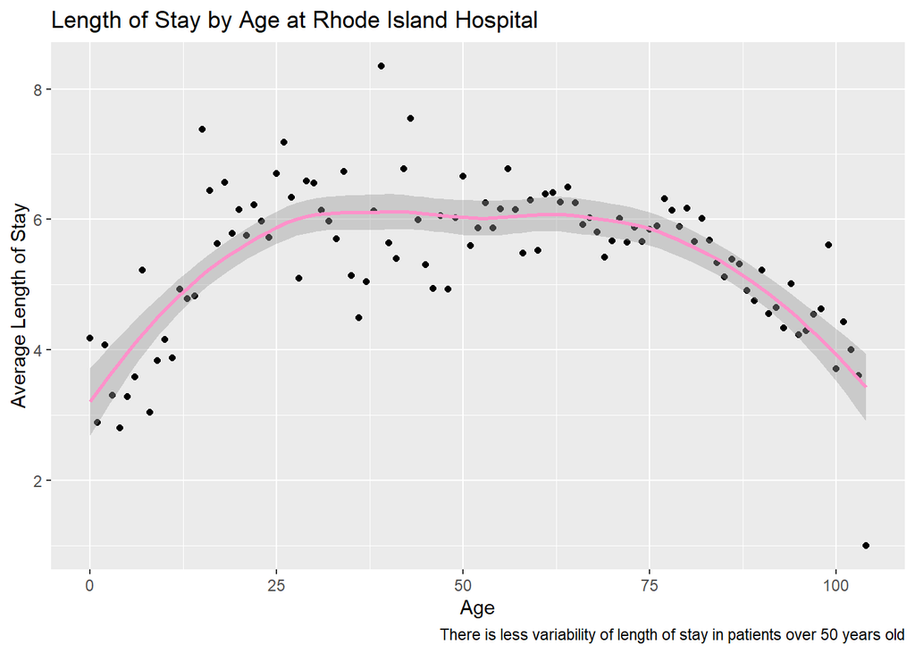

```r
df %>% filter(provider==7205) %>%
  group_by(age) %>%
  summarise(average_los = mean(los)) %>%
  ggplot() +
  geom_point(mapping = aes(x = age, y = average_los))+
  geom_smooth(mapping = aes(x = age, y = average_los), color = "#FF91CA")+
  labs(x = 'Age',
       y = 'Average Length of Stay',
       title = 'Length of Stay by Age at Rhode Island Hospital',
       caption = 'There is less variability of length of stay in patients over 50 years old')+
  ggsave("plot4.png")
```

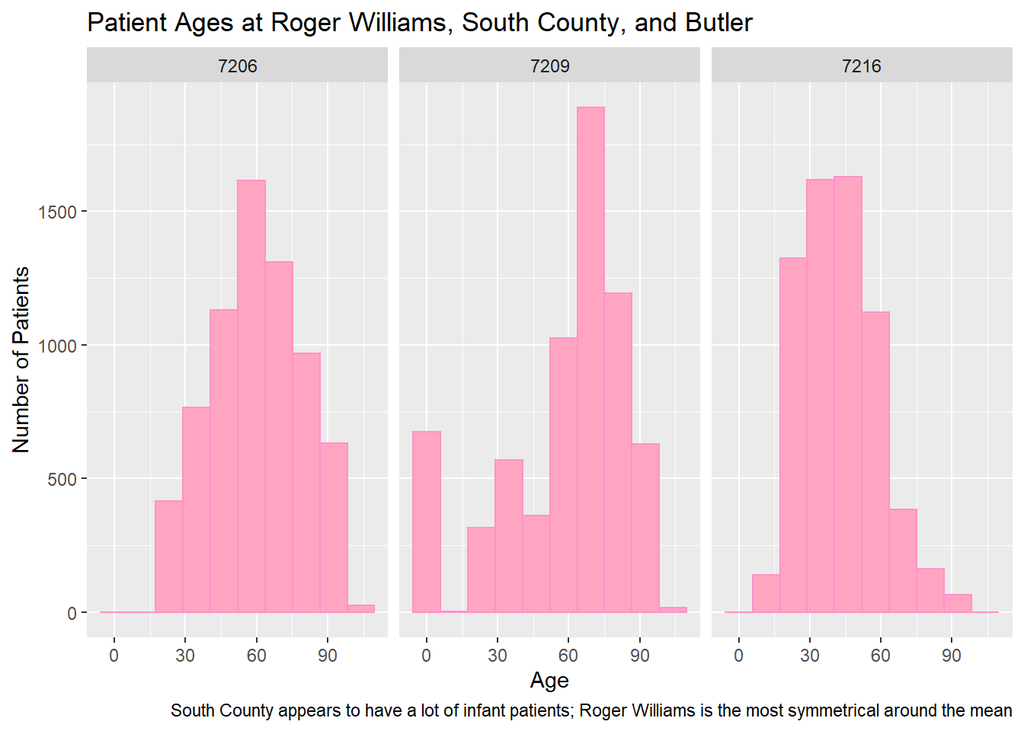

```r
df %>% filter(provider==7206 | provider==7209 | provider == 7216) %>%
  ggplot() +
  geom_histogram(mapping = aes(x = age), bins = 10, color = "#FF91CA", fill = "#FFA5C2") +
  facet_wrap(~provider)+
  labs(x = "Age",
       y = "Number of Patients",
       title = "Patient Ages at Roger Williams, South County, and Butler",
       caption = "South County appears to have a lot of infant patients; Roger Williams is the most symmetrical around the mean")+
  ggsave("plot5.png")
```

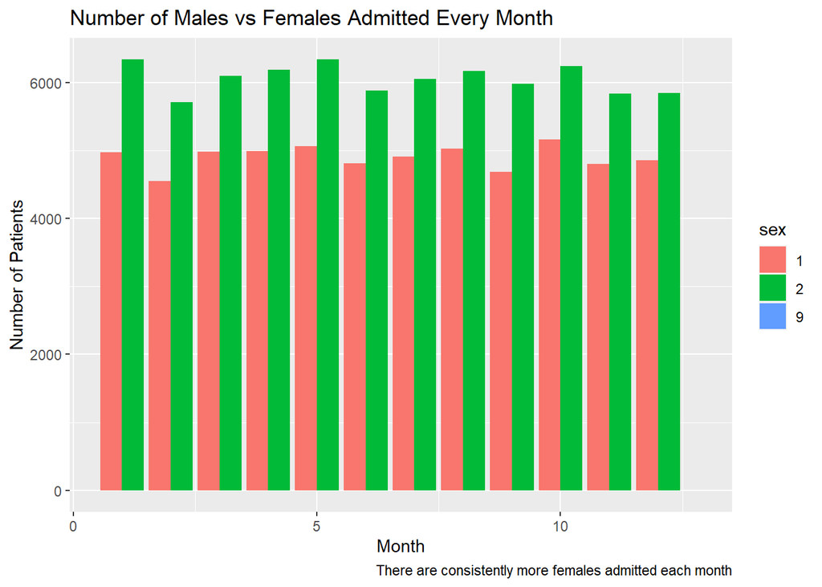

```r
df %>% ggplot() +
  geom_bar(mapping = aes(x = moa, fill = sex), position = 'dodge')+
  labs(x = "Month",
       y = "Number of Patients",
       title = "Number of Males vs Females Admitted Every Month",
       caption = "There are consistently more females admitted each month")+
  ggsave("plot6.png")
```

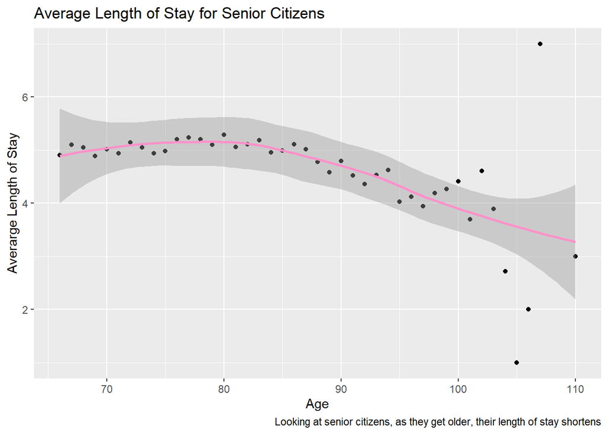

```r
df %>% filter(age>65) %>%
  group_by(age) %>%
  summarise(average_los = mean(los)) %>%
  ggplot() +
  geom_point(mapping = aes(x = age, y = average_los))+
  geom_smooth(mapping = aes(x = age, y = average_los), color = "#FF91CA")+
  labs(x = "Age",
       y = "Averarge Length of Stay",
       title = "Average Length of Stay for Senior Citizens",
       caption = "Looking at senior citizens, as they get older, their length of stay shortens")+
  ggsave("plot7.png")
```

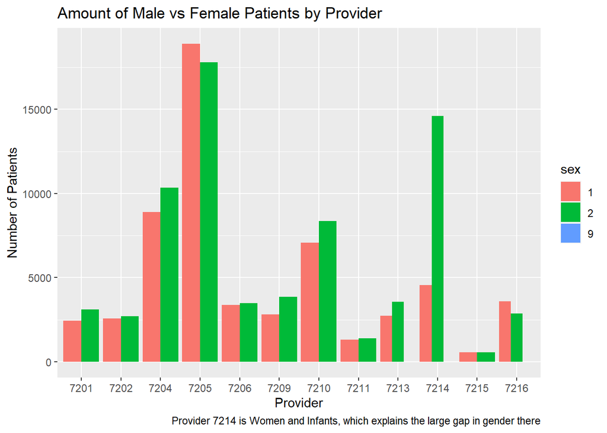

```r
df %>%
  ggplot() +
  geom_bar(mapping = aes(x = provider, fill = sex), position = 'dodge')+
  labs(x = "Provider",
       y = "Number of Patients",
       title = "Amount of Male vs Female Patients by Provider",
       caption = "Provider 7214 is Women and Infants, which explains the large gap in gender there")+
  ggsave("plot8.png")
```

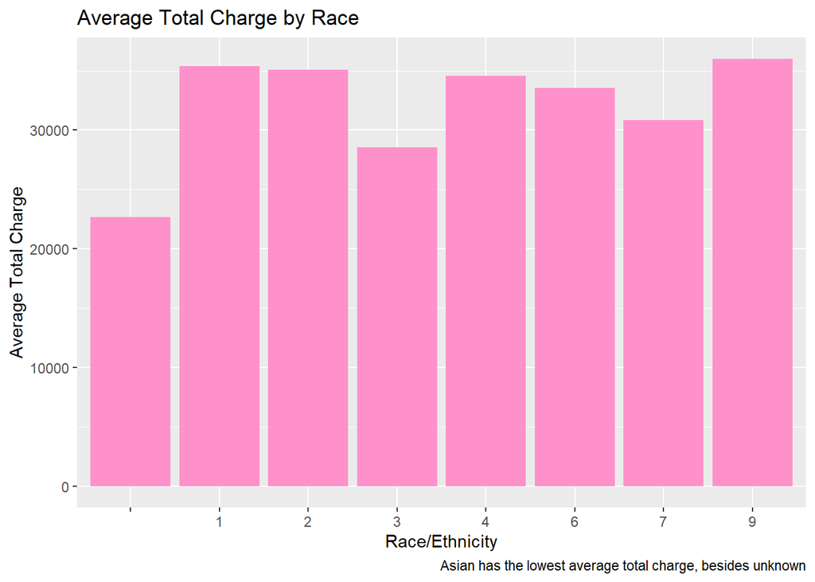

```r
df %>%
  group_by(raceethn) %>%
  summarise(average_tot = mean(tot)) %>%
  ggplot() +
  geom_col(mapping = aes(x = raceethn, y = average_tot), fill = "#FF91CA")+
  labs(x = "Race/Ethnicity",
       y = "Average Total Charge",
       title = "Average Total Charge by Race",
       caption = "Asian has the lowest average total charge, besides unknown")+
  ggsave("plot9.png")
```

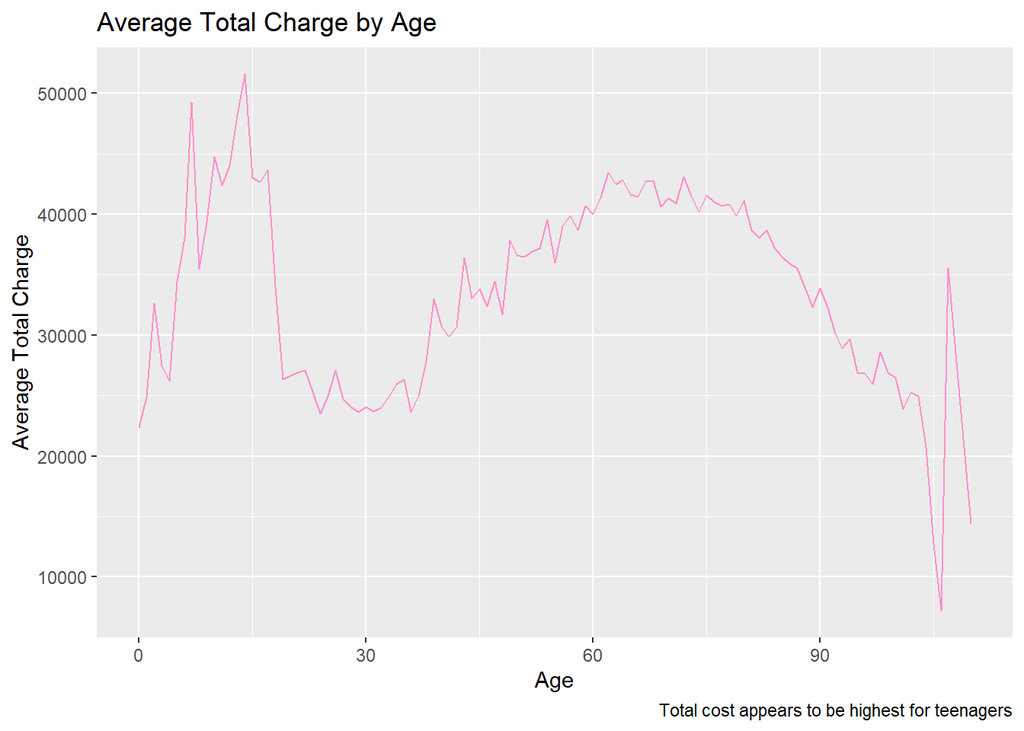

```r
df %>% group_by(age) %>%
  summarise(average_tot = mean(tot)) %>%
  ggplot() +
  geom_line(mapping = aes(x = age, y = average_tot), color = "#FF91CA")+
  labs(x = "Age",
       y = "Average Total Charge",
       title = "Average Total Charge by Age",
       caption = "Total cost appears to be highest for teenagers")+
  ggsave("plot10.png")
```

2. Make an animation

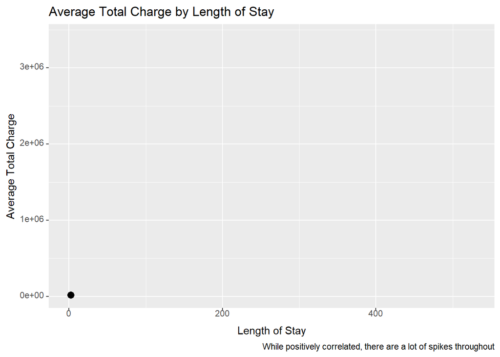

```r
library(gganimate)
df %>% group_by(los) %>%
  summarise(average_tot = mean(tot)) %>%
  ggplot(aes(x = los, y = average_tot)) +
  geom_line()+
  geom_point(size = 3)+
  transition_reveal(los)+
  labs(x = "Length of Stay",
       y = "Average Total Charge",
       title = "Average Total Charge by Length of Stay",
       caption = "While positively correlated, there are a lot of spikes throughout")
```

## III. Predictive Models

Continue with the data from part I. Use the follows as the target and input variables:

*Target Variable*: Create the target variable taking value of

- `low` if the total charge of a patient (`tot`) is smaller than the median of the total charge, and
- `high` otherwise.

*Input Variables*:

```r
library(tidyverse)

df$target <- case_when(
  df$tot < median(df$tot) ~ 'low',
  TRUE ~ 'high'
)

df <- df %>% select(age, sex, raceethn, provider, moa, mod, admtype, campus, los, target)
df <- df %>% drop_na(raceethn, admtype)


library(caret)
set.seed(2020)
splitIndex <- createDataPartition(df$target, p = 0.90,
                                  list = FALSE)
df_train <- df[splitIndex, ]
df_test <- df[-splitIndex, ]
```

2. Train a decision tree using `rpart`. Plot the decision tree. Plot the variable importance ranked by the tree.

```r
library(rpart)
tree_model <- rpart(target ~., data = df_train,
                    control = rpart.control(maxdepth = 3))
library(rattle)
```

[figure not shown]

```r
fancyRpartPlot(tree_model)
```

```r
tree_model$variable.importance
```

```
##          los      admtype     provider          age       campus     raceethn
## 1.592985e+04 4.235902e+03 3.539684e+03 2.010839e+03 8.039562e+02 1.686954e+02
##          sex
## 2.902711e-01
```

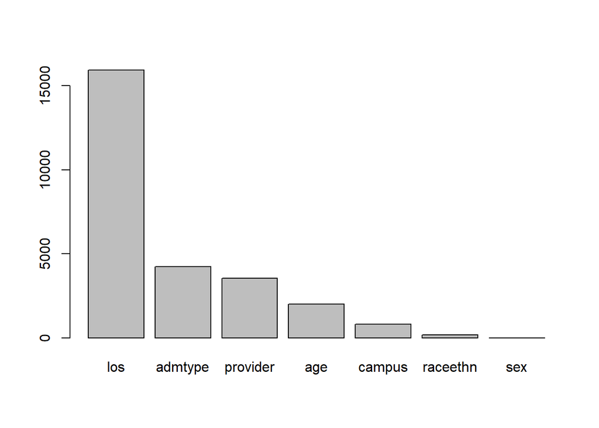

```r
barplot(tree_model$variable.importance)
```

3. Using caret for this question. Set `Training Control` to be: Use Cross-Validation of 5 folds across all models. Train & tune at least 3 different models (i.e. three different values for `method=` in the train function of caret). Plot the hyper-parameter tuning plots for each model.

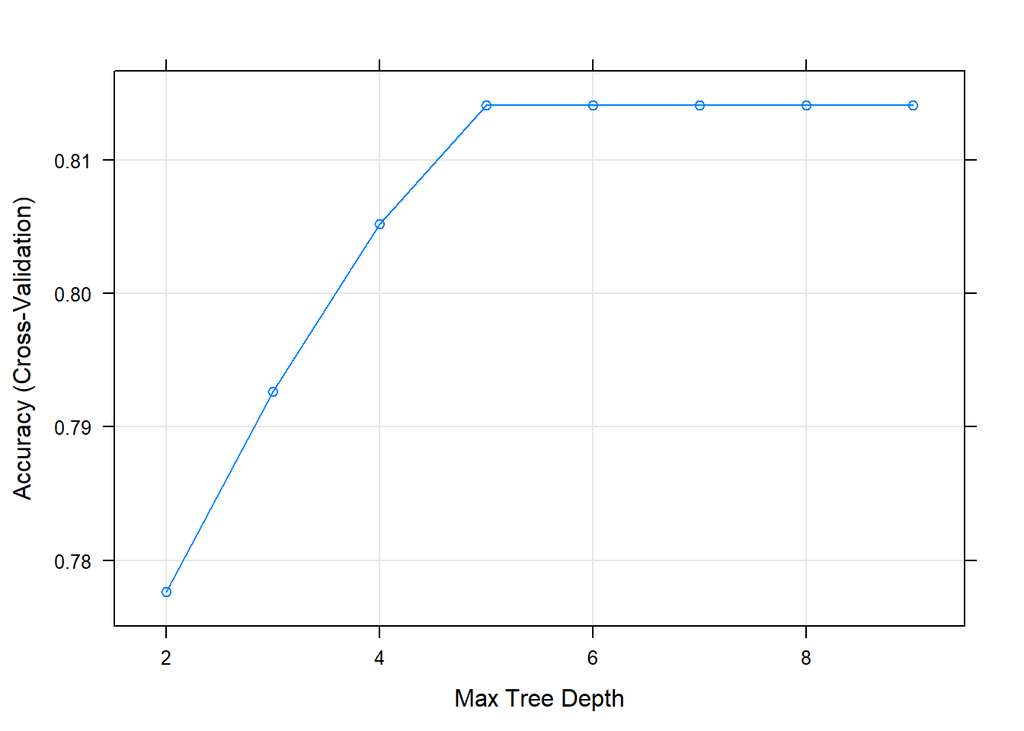

```r
tuneGrid = expand.grid(maxdepth = 2:9)
trControl = trainControl(method = "cv",
                         number = 5)

tree <- train(target~., data = df_train,
                        method = "rpart2",
                        trControl = trControl,
                        tuneGrid = tuneGrid)

plot(tree)
```

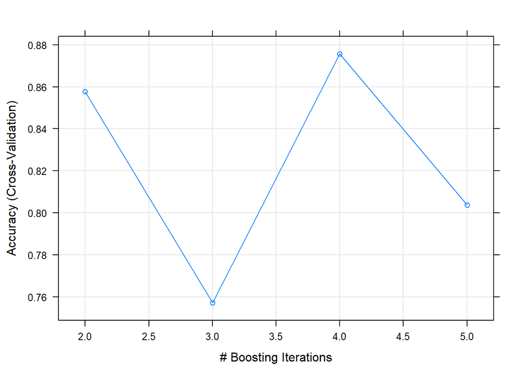

```r
tuneGrid = expand.grid(nIter = 2:5)
trControl = trainControl(method = "cv",
                         number = 5)

library(caret)

logit <- train(target~., data = df_train,
                        method = "LogitBoost",
                        trControl = trControl,
                        tuneGrid = tuneGrid)

plot(logit)
```

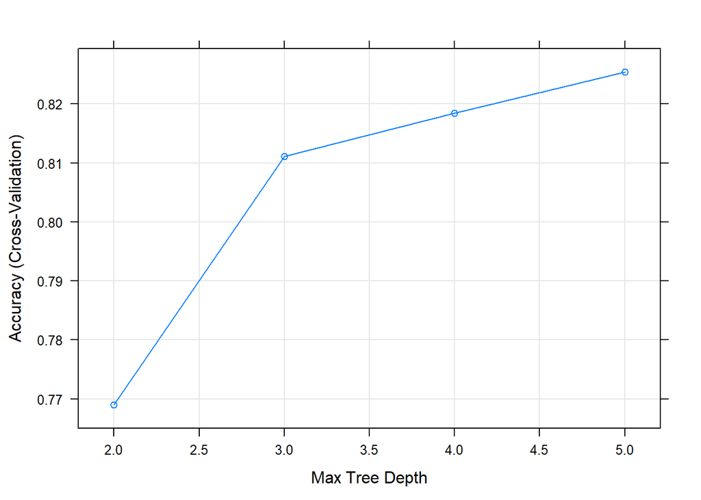

```r
trControl = trainControl(method = "cv",
                         number = 5)
tuneGrid = expand.grid(maxdepth = 2:5,
                       mstop = 3)

blackboost <- train(target~., data = df_train,
                        method = "blackboost",
                        trControl = trControl,
                        tuneGrid = tuneGrid)

plot(blackboost)
```

4. Plot the comparison of the models in 3.

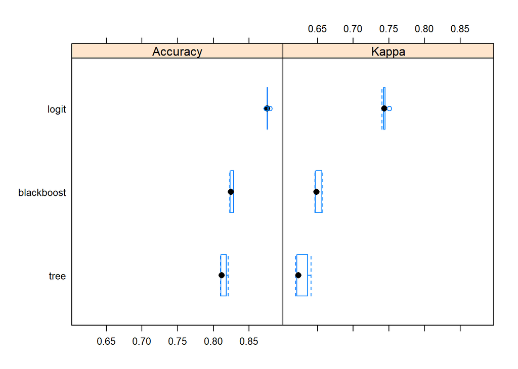

```r
results <- resamples(list(tree = tree,
                          logit = logit,
                          blackboost = blackboost))
bwplot(results)
```

5. What is your final selection for the model? Test the accuracy of your final model on the test data.

```r
pred <- predict(logit, df_test)
cm <- confusionMatrix(data = factor(pred), reference = factor(df_test$target), positive = "low")
cm$overall[1]
```

```
##  Accuracy
## 0.8796983
```

6. Create another `target` variable (binary), decide the input variables and redo 1 to 5.

```r
library(tidyverse)

df <- read_csv("midterm.csv")
df$target <- case_when(
  df$los < 7 ~ 'short',
  TRUE ~ 'long'
)

df <- df %>% select(age, sex, raceethn, provider, moa, mod, admtype, campus, target)
df <- df %>% drop_na(raceethn, admtype)


library(caret)

set.seed(2020)
splitIndex <- createDataPartition(df$target, p = 0.90,
                                  list = FALSE)
df_train <- df[splitIndex, ]
df_test <- df[-splitIndex, ]
```

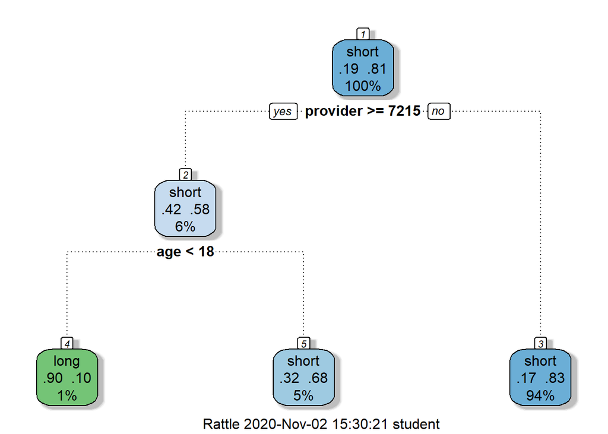

```r
library(rpart)
tree_model <- rpart(target ~., data = df_train,
                    control = rpart.control(maxdepth = 3))
library(rattle)
fancyRpartPlot(tree_model)
```

```r
tree_model$variable.importance
```

```
##     provider          age          sex
## 1272.7358002  593.2254088    0.1174294
```

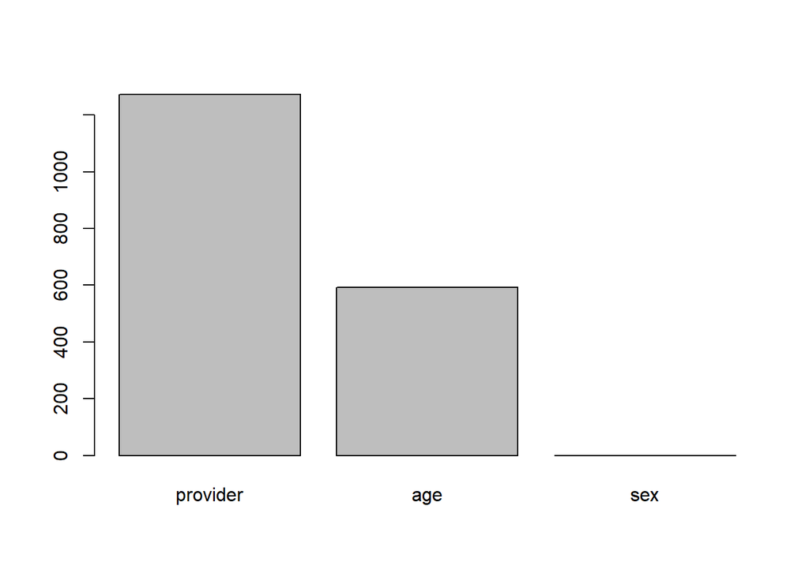

```r
barplot(tree_model$variable.importance)
```

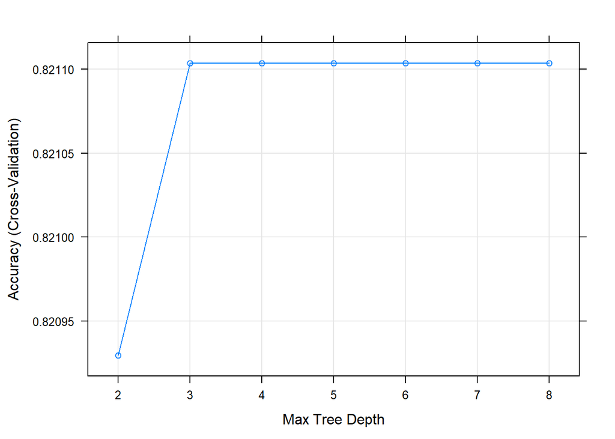

```r
tuneGrid = expand.grid(maxdepth = 2:8)
trControl = trainControl(method = "cv",
                         number = 5)

tree <- train(target~., data = df_train,
                        method = "rpart2",
                        trControl = trControl,
                        tuneGrid = tuneGrid)

plot(tree)
```

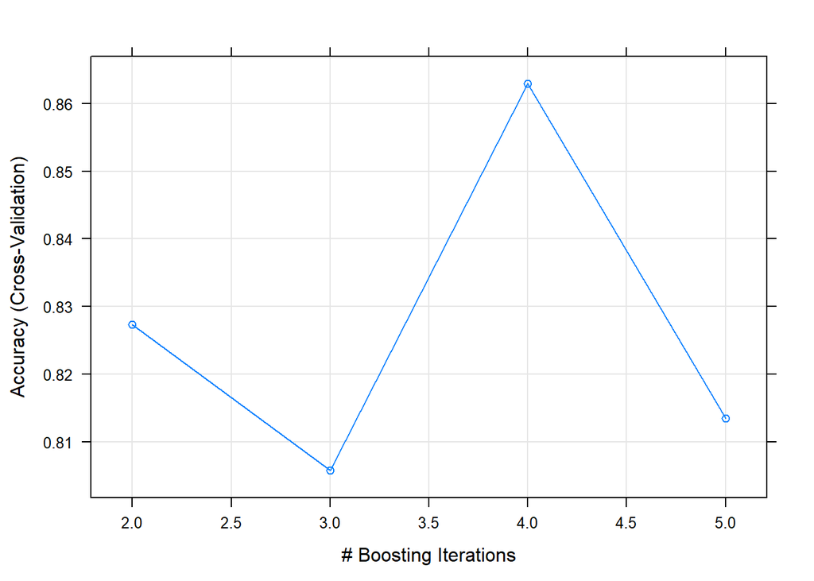

```r
tuneGrid = expand.grid(nIter = 2:5)
trControl = trainControl(method = "cv",
                         number = 5)

library(caret)

logit <- train(target~., data = df_train,
                        method = "LogitBoost",
                        trControl = trControl,
                        tuneGrid = tuneGrid)

plot(logit)
```

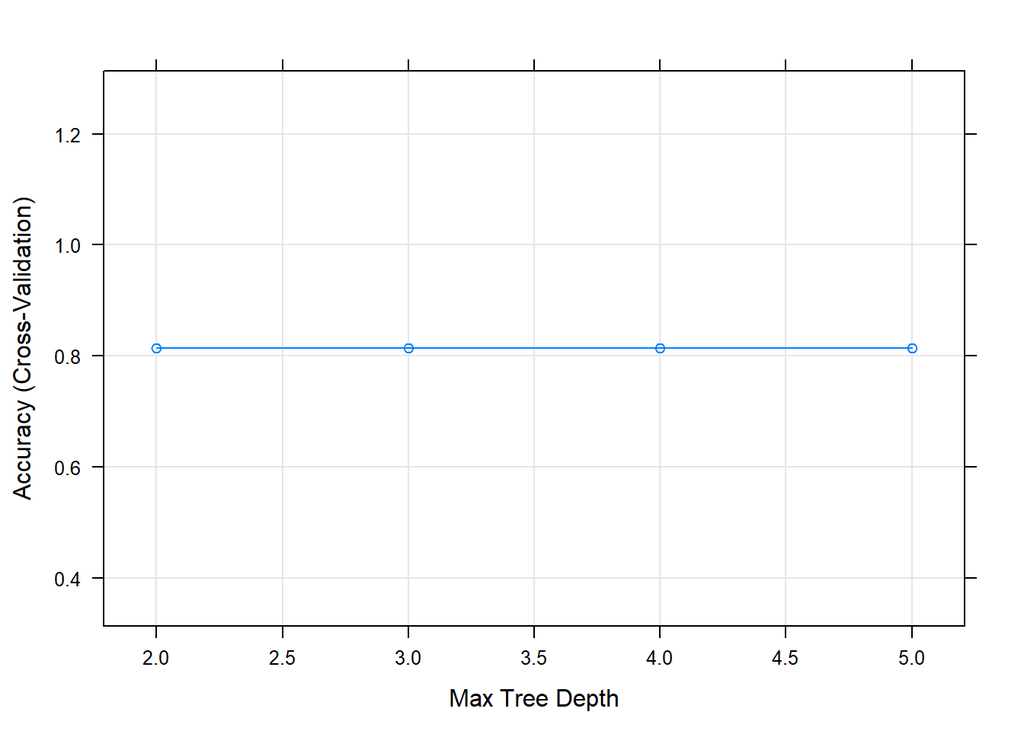

```r
trControl = trainControl(method = "cv",
                         number = 5)
tuneGrid = expand.grid(maxdepth = 2:5,
                       mstop = 3)

blackboost <- train(target~., data = df_train,
                        method = "blackboost",
                        trControl = trControl,
                        tuneGrid = tuneGrid)

plot(blackboost)
```

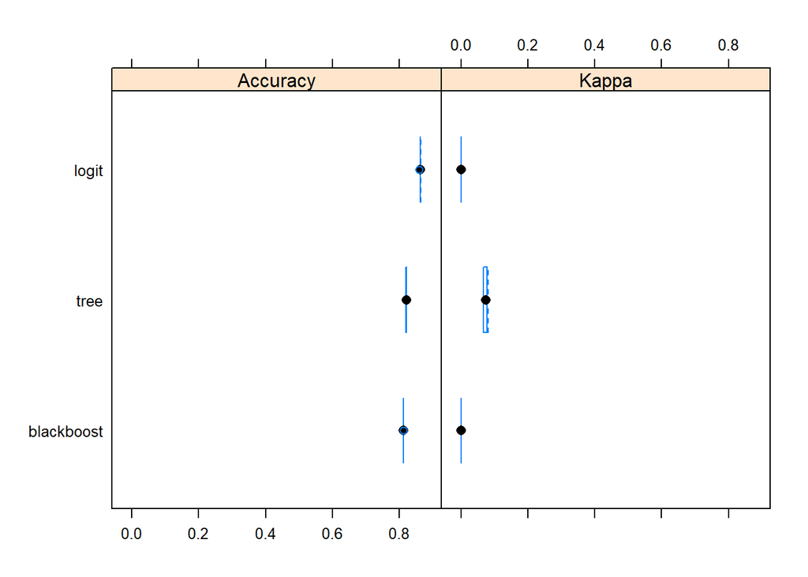

```r
results <- resamples(list(tree = tree,
                          logit = logit,
                          blackboost = blackboost))
bwplot(results)
```

```r
pred <- predict(logit, df_test)
cm <- confusionMatrix(data = factor(pred), reference = factor(df_test$target), positive = "short")
cm$overall[1]
```

```
##  Accuracy
## 0.8659965
```